# TP1_Grupo-7

SAMANTHA HORWITZ - MATÍAS RODRIGUEZ MENDOZA

## Introducción

Los datos que se van a utilizar para la elaboración de este informe corresponden a la Encuesta de Uso del Tiempo generada por la Dirección General de Estadística y Censos del Ministerio de Economía y Finanzas del Gobierno de la Ciudad de Buenos Aires (GCBA) en el año 2016.

La encuesta releva información sobre el tiempo destinado a la realización de diversas actividades de la población de la Ciudad de Buenos Aires.

Como antecedente se registra una encuesta anterior realizada en el año 2005.

## Exploración de los datos

```r
# Código para cargar o leer los datos

datos_uso_tiempo <- read_csv("datos/encuesta_uso_tiempo_2016.csv",
                             locale = locale(encoding = "ISO-8859-1"))
```

## Hipótesis 1

Nuestro interés principal reside en el estudio del tiempo dedicado a tareas laborales. En primer lugar, queremos observar si, en un día laborable, existe correlación entre la cantidad de horas dedicadas al trabajo y la realización de actividades recreativas y de cuidado personal.

Para poder observar esta situación construimos nuevas variables para ver como se reparte la población de acuerdo a la cantidad de horas trabajadas y las dedicadas a la recreación

Las categorías estarán armadas de la siguiente manera:

Menos de 8 horas trabajadas y menos de una hora de recreación -> 1

Menos de 8 horas trabajadas y entre 1 y dos horas de recración -> 2

Menos de 8 horas trabajadas y 2 o más horas de recreación -> 3

8 horas o más trabajadas y menos de una hora de recreación -> 4

8 horas o más trabajadas y entre 1 y dos horas de recración -> 5

8 horas o más trabajadas y 2 o más horas de recreación -> 6

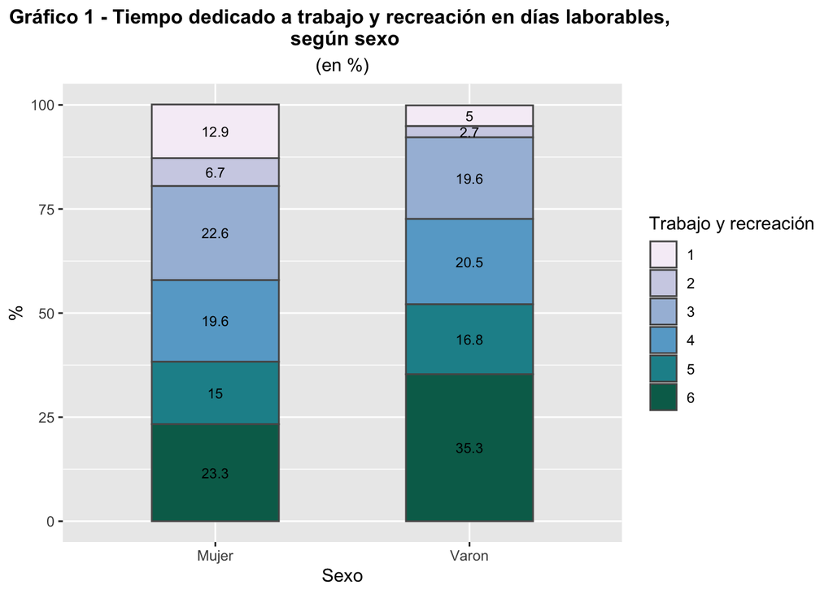

```r
datos_uso_tiempo <- datos_uso_tiempo %>%
  filter (dia_laborable == "Día laborable") %>%
  mutate(trabajo_recreacion = case_when(
    trabajo_pago < 8 & recreacion < 1 ~ 1,
    trabajo_pago < 8 & recreacion >= 1 & recreacion < 2 ~ 2,
    trabajo_pago < 8 & recreacion >= 2 ~ 3,
    trabajo_pago >= 8 & recreacion < 1 ~ 4,
    trabajo_pago >= 8 & recreacion >= 1 & recreacion < 2 ~ 5,
    trabajo_pago >= 8 & recreacion >= 2 ~ 6,
  ))


datos_uso_tiempo %>%
  group_by(sexo, trabajo_recreacion) %>%
  summarise(n = n()) %>%
  group_by(sexo) %>%
  mutate(prop = n/sum(n)*100) %>%
  mutate(prop = round(prop, digits = 1)) %>%
  ggplot(aes(sexo, prop, fill = factor(trabajo_recreacion))) +
  geom_bar(width = 0.5, color="gray34", stat='identity', position = "stack") +
  scale_fill_brewer(palette = "PuBuGn", name = "Trabajo y recreación") +
  geom_text(aes(label = prop, group = factor(trabajo_recreacion)),size = 3, weight = "bold", position = position_stack(0.5)) +
  labs(title = "Gráfico 1 - Tiempo dedicado a trabajo y recreación en días laborables, \n según sexo",
       subtitle = "(en %)",
       x = "Sexo",
       y = "%",
       size = 3,
       color = "Trabajo y recreación",
       shape = "Trabajo y recreación") +
  theme(plot.title = element_text(hjust = 0.5,
                                  lineheight = 0.9,
                                  size = 12,
                                  face = "bold"),
        plot.subtitle = element_text(hjust = 0.5),
        legend.position = "right")
```

Sin embargo, llama la atención los valores extremos: los varones trabajan más de 8 hs y dedican más de 2 hs a la recreación un **51,5% más** que las mujeres (V: 35,3% vs. M: 23,3%). Por el contrario, la cantidad de mujeres que trabaja menos de 8 hs y dedican menos de 1 hs a la recreación **más que duplica** la cantidad de varones (M: 12,9% vs. V: 5%).

## Hipótesis 2

Como segunda hipótesis, nos interesa corroborar si la cantidad de horas destinadas a tareas de cuidado tiene correlación directa con la cantidad de horas que se dedican al trabajo no remunerado, y si esta relación, además, es más sensible según el sexo.

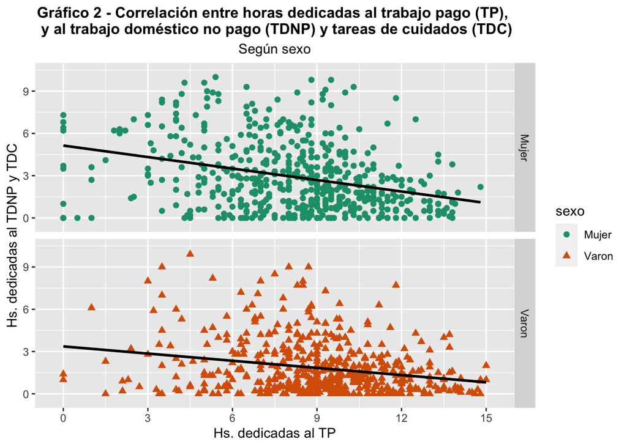

```r
datos_uso_tiempo %>%
  filter(dia_laborable == "Día laborable") %>%
  mutate(tdnp_cuidados = trabajo_domestico_no_pago + tareas_cuidados) %>%
  ggplot(aes(trabajo_pago, tdnp_cuidados))+
  geom_point(aes(color = sexo, shape = sexo), size = 2) +
  geom_smooth(method = "lm", se = FALSE, color = "black") +
  scale_x_continuous(limits = c(0, 15), breaks = seq(0, 15, 3), expand = c(0, 1)) +
  scale_y_continuous(limits = c(0, 10), breaks = seq(0, 10, 3), expand = c(0, 1)) +
  scale_color_brewer(palette = "Dark2") +
  labs(title = "Gráfico 2 - Correlación entre horas dedicadas al trabajo pago (TP), \n y al trabajo doméstico no pago (TDNP) y tareas de cuidados (TDC)",
       subtitle = "Según sexo",
       x = "Hs. dedicadas al TP",
       y = "Hs. dedicadas al TDNP y TDC") +
       theme(plot.title = element_text(hjust = 0.5,
                                       lineheight = 0.9,
                                       size = 12,
                                       face = "bold"),
             plot.subtitle = element_text(hjust = 0.5)) +
  facet_grid("sexo")
```

## Hipótesis 3

Partiendo del supuesto general -y corroborado en los análisis previos- que los varones dedican más horas que las mujeres al trabajo remunerado, mientras que la media de horas de trabajo doméstico no pago es mayor en mujeres que en varones, consideramos que esto no describe con fidelidad el fenómeno actual. Con lo cual, se buscará verificar -a partir del planteo de la tercera hipótesis- la relación inversa que existe entre el nivel de ingreso de los hogares, y la brecha entre la media de horas de trabajadas (remuneradas y no remuneradas). Dicho de otra forma, se intuye que a medida que aumenta el nivel de ingreso de los hogares, el tiempo dedicado a trabajo remunerado y no remunerado por hombres y mujeres se va equiparado.

*Nota metodológica: dato anómalo*

Para esta última hipótesis pensábamos utilizar la variable *quintil_ingeso* del dataset que registra a qué quintil pertenece cada hogar. Sin embargo al indagar sobre los datos descubrimos que en todos los registros figura la categoría **5to Quintil** lo cuál no sólo es es metodológicamente incorrecto, sino que advertimos que podría ser una anomalía de la base de datos, por lo que el presunto error condicionó nuestra línea investgativa. En ese marco, decidimos sortear el problema utilizando la variable *nivel_educativo* como proxy de análisis del nivel de ingresos del hogar y de la persona encuestada.

```r
horas_segun_nivel_educativo <- datos_uso_tiempo %>%
  filter(dia_laborable == "Día laborable") %>%
  select(sexo, trabajo_pago, trabajo_domestico_no_pago, nivel_educativo)  %>%
  group_by(sexo, nivel_educativo) %>%
  summarise(horas_trabajo_rem = mean(trabajo_pago),
            horas_trabajo_domestico = mean(trabajo_domestico_no_pago),
            total_horas = mean(trabajo_pago + trabajo_domestico_no_pago)) %>%
  arrange(horas_trabajo_rem)
```

```r
max_horas_trabajadas <- max(horas_segun_nivel_educativo$horas_trabajo_rem)
max_horas_trabajo_domestico <- max(horas_segun_nivel_educativo$horas_trabajo_domestico)

horas_segun_nivel_educativo |>
  gt() |>
  tab_header(
    title = md("**Horas dedicadas al trabajo remunerado y al trabajo doméstico no pago**"),
    subtitle = md("**Según sexo y nivel educativo**")
  ) |>
  cols_label(
    nivel_educativo = "Sexo/Nivel educativo",
    horas_trabajo_domestico = "Trabajo doméstico no pago",
    horas_trabajo_rem = "Trabajo remunerado", total_horas = "Total de horas"
    )  |>
  tab_source_note(
    source_note = "Fuente: Elaboración propia en base a la Encuesta de Uso del Tiempo 2016
    del GCBA"
   ) |>
  fmt_number(
    columns = c(horas_trabajo_domestico, horas_trabajo_rem, total_horas),
    decimals = 1,
    dec_mark = ",",
    sep_mark = "."
  ) |>
  tab_style(
    style = list(
      cell_text(color = "darkred", weight = "bold")
    ),
    locations = cells_body(
      columns = horas_trabajo_rem,
      rows = horas_trabajo_rem == max_horas_trabajadas
    )
  ) |>
  tab_style(
    style = list(
      cell_text(color = "darkred", weight = "bold")
    ),
    locations = cells_body(
      columns = horas_trabajo_domestico,
      rows = horas_trabajo_domestico == max_horas_trabajo_domestico
    )
  ) |>
  tab_style(
    style = list(
      cell_text(indent = px(10))
    ),
    locations = cells_body(
      columns = nivel_educativo
    )
  ) |>
  cols_align(
    align = "left",
    columns = nivel_educativo
  ) |>
  cols_align(
    align = "center",
    columns = c(horas_trabajo_rem, horas_trabajo_domestico, total_horas)
  ) |>
  tab_options(
    column_labels.border.top.color = "white",
    column_labels.border.top.width = px(3),
    column_labels.border.bottom.color = "black",
    table.border.top.color = "white",
    table.border.top.width = px(3),
    table.border.bottom.color = "white",
    table.border.bottom.width = px(3)
  )
```

**Horas dedicadas al trabajo remunerado y al trabajo doméstico no pago**

**Según sexo y nivel educativo**

| Sexo/Nivel educativo | Trabajo remunerado | Trabajo doméstico no pago | Total de horas |
| --- | --- | --- | --- |
| Mujer |  |  |  |
| Secundario incompleto | 7,8 | 2,8 | 10,6 |
| Secundario completo/Superior incompleto | 8,0 | 2,0 | 10,0 |
| Superior completo | 8,3 | 2,2 | 10,5 |
| Varon |  |  |  |
| Secundario incompleto | 9,1 | 1,4 | 10,5 |
| Secundario completo/Superior incompleto | 9,1 | 1,2 | 10,3 |
| Superior completo | 9,4 | 1,2 | 10,7 |

Fuente: Elaboración propia en base a la Encuesta de Uso del Tiempo 2016 del GCBA

Corroborada la hipótesis que verifica que los varones destinan en promedio más horas que las mujeres al trabajo remunerado, y las mujeres destinan más horas al trabajo doméstico no pago, se busca estudiar en esta última instancia si existe una relación inversa entre el nivel educativo y la brecha entre trabajo pago y no pago, y si dicha relación se profundiza según sexo.

Si bien el rango de valores de la variable “nivel_educativo” no distingue entre terminación o no de la primaria, ni tampoco releva información sobre finalización de posgrados, los datos permiten acceder a conclusiones interesantes: tanto en hombres como en mujeres la cantidad de horas dedicadas al trabajo remuerado aumenta acorde al nivel educativo alcanzado. No obstante, existe una brecha de género, al estudiar en términos absolutos la cantidad de horas que los hombres y las mujeres le dedican al trabajo remunerado respecto al doméstico no pago.

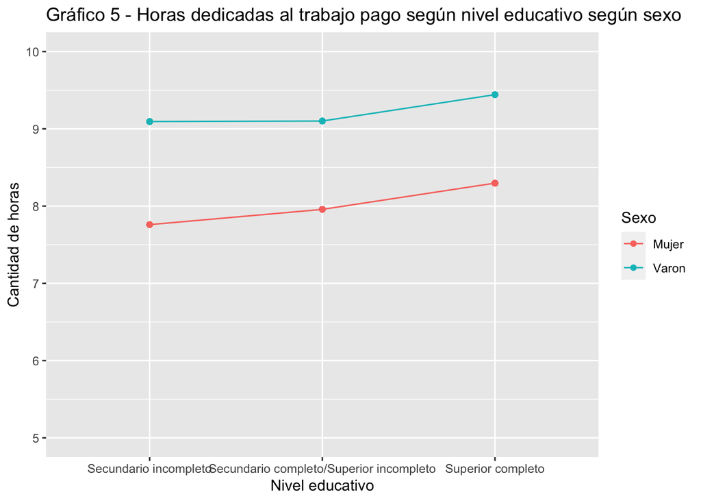

```r
datos_uso_tiempo %>%
  filter(dia_laborable == "Día laborable") %>%
  select(sexo, trabajo_pago, trabajo_domestico_no_pago, nivel_educativo)  %>%
  group_by(sexo, nivel_educativo) %>%
  mutate(horas_trabajo_rem = mean(trabajo_pago)) %>%
  ggplot(aes(nivel_educativo, horas_trabajo_rem)) +
  geom_line(aes(group = sexo, color=sexo)) +
  geom_point(aes(color=sexo)) +
  scale_color_discrete(name = "Sexo") +
  scale_x_discrete(limits = c("Secundario incompleto", "Secundario completo/Superior incompleto", "Superior completo")) +
  scale_y_continuous(limits = c(5, 10)) +
  labs(title = "Gráfico 5 - Horas dedicadas al trabajo pago según nivel educativo según sexo",
       x = "Nivel educativo",
       y = "Cantidad de horas")
```

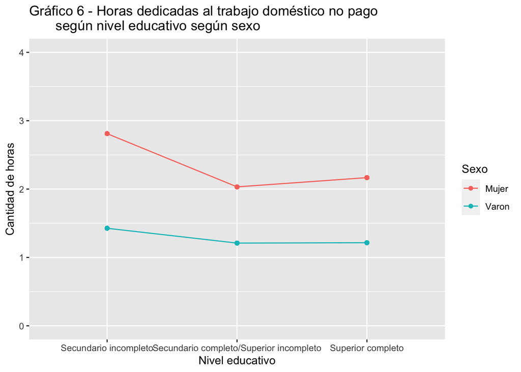

```r
datos_uso_tiempo %>%
  filter(dia_laborable == "Día laborable") %>%
  select(sexo, trabajo_pago, trabajo_domestico_no_pago, nivel_educativo)  %>%
  group_by(sexo, nivel_educativo) %>%
  mutate(horas_trabajo_no_rem = mean(trabajo_domestico_no_pago)) %>%
  ggplot(aes(nivel_educativo, horas_trabajo_no_rem)) +
  geom_line(aes(group = sexo, color=sexo)) +
  geom_point(aes(color=sexo)) +
  scale_color_discrete(name = "Sexo") +
  scale_x_discrete(limits = c("Secundario incompleto", "Secundario completo/Superior incompleto", "Superior completo")) +
  scale_y_continuous(limits = c(0, 4)) +
  labs(title = "Gráfico 6 - Horas dedicadas al trabajo doméstico no pago
       según nivel educativo según sexo",
       x = "Nivel educativo",
       y = "Cantidad de horas")
```

Ahora bien, de los gráficos 5 y 6 se confirma también la brecha de género verificada en hipótesis anteriores, que se recrudece del análisis de este último cruce de datos: quienes más horas dedican al trabajo remunerado son los hombres con nivel educativo superior completo, mientras que las mujeres con secundario incompleto son quienes más horas destinan al trabajo doméstico no pago.